# From a step test to lactate thresholds

lactater cheatsheet, page 1 of 2

## Record the test

One row per stage, the lactate taken in the last 30 s. The resting sample is the row with intensity 0.

| intensity | lactate | heart_rate | rpe |
| --- | --- | --- | --- |
| 0 | 0.93 | 96 | 6 |
| 50 | 0.98 | 114 | 7 |
| 75 | 1.23 | 134 | 8 |
| … | … | … | … |
| 191 | 8.64 | 198 | 19 |

**recording_sheet()**

A printable sheet, a web form and a CSV template with these columns.

**read_recording()**

Reads the .xlsx of the form: stages, recovery, the athlete.

**demo_data**

The test above; `lactate_tests` has 16 more, four sports.

### A last stage not completed

Enter its time-weighted intensity: the last completed stage plus the increment × seconds done / seconds of a stage. Or leave it out with `max_intensity`.

### Make tests comparable

Same diet and training in the 24 to 48 h before, same time of day, stages of 3 min or more, two or three stages below the first rise, the same sampling site, sample type and analyzer every time.

Sources and the strength of each point: the *Best practices* article.

### Sports and units

| sport | Intensity | Also shown |
| --- | --- | --- |
| cycling | W | per kg with a body mass |
| running | km/h | pace, min/km |
| swimming | m/s | pace, min/100 m |
| rowing | W | 500 m split |

## Estimate every threshold

```
results <- lactate_threshold(
  demo_data, intensity, lactate, heart_rate,
  rpe_column = rpe, sport = "cycling"
)
```

| Method | What it finds |
| --- | --- |
| Log-log | Where two lines through log lactate and log intensity cross |
| OBLA 2.0–4.0 | A fixed lactate, 2 to 4 mmol/L |
| Bsln+ 0.5–1.5 | 0.5 to 1.5 mmol/L above the resting value |
| D<sub>max</sub> family | The point furthest below a line to the last stage |
| LTP1, LTP2 | The turn points of three straight segments |
| LT<sub>ratio</sub>, IAT | The lowest lactate / intensity; 1.5 mmol/L above it |
| Keul, Simon | Running only: where the curve rises 1.26 or 1 mmol/L per km/h |
| Stegmann | A tangent from recovery to the curve |

### Useful arguments

**method**

Some methods only, e.g. `c("Dmax", "LTP")`

**fit**

The curve: polynomial (3rd or 4th degree) or B-spline

**sport**

cycling, rowing (W), running (km/h), swimming (m/s)

**ci = TRUE**

Bootstrap confidence intervals

**recovery**

Recovery samples and `stage_duration`, for Stegmann

**sample**

blood, plasma, sweat or interstitial fluid

**.by**

Many tests in one call, e.g. `.by = "athlete"`

### Fine-tune the methods

**fixed**

OBLA targets, mmol/L; default 2 to 4

**baseline_plus**

Bsln+ rises, mmol/L; default 0.5, 1, 1.5

**iat_rise**

The IAT rise above LT<sub>ratio</sub>; default 1.5

**dmax_anchor**

Where the D<sub>max</sub> lines start and end

**ltp_breakpoints**

1 for a test that stopped before LTP2

**max_intensity**

Leave out stages above it

## Look, then check

```
autoplot(results)                     # every method
autoplot(results, method = "ModDmax") # one method
```

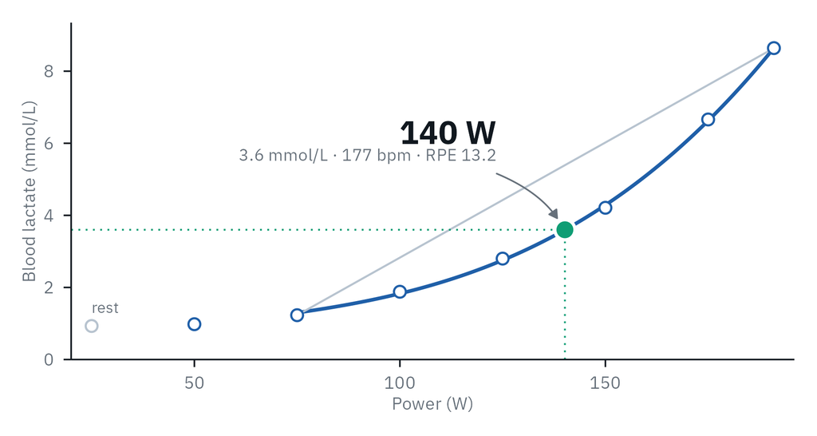

One method: the curve, its line, and the threshold at 140 W.

**lactate_checks()**

A checklist of what is easy to miss: missing rest, a lactate dip, a final plateau

**lactate_diagnostics()**

Residuals, influential stages, how far each threshold moves without one stage

**lactate_fit_quality()**

Which curve predicts the stages best

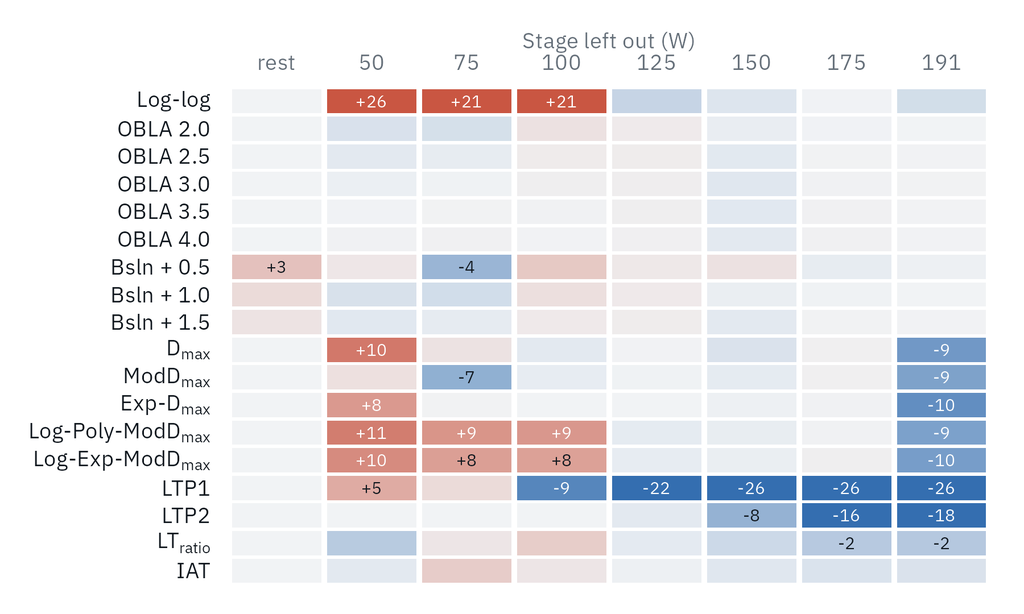

Leave one stage out: red, the threshold rises without that stage; blue, it falls; dark, it rests on it.

# Using the thresholds

lactater cheatsheet, page 2 of 2

## Zones and training

```
zones <- lactate_zones(results, model = 5)
## LT1, LT2: from lactate_threshold(lt1 =, lt2 =)
```

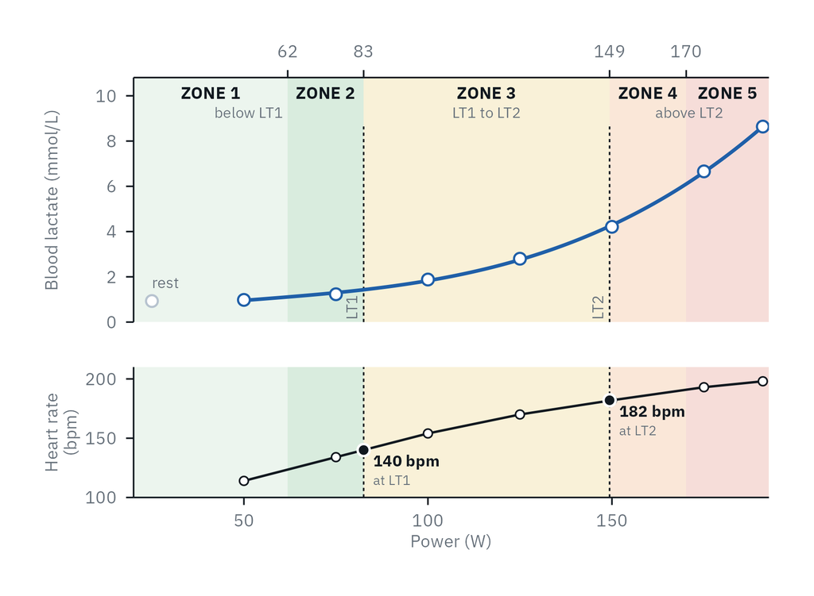

LT1 and LT2 split the intensities into moderate, heavy and severe; five zones split the outer two. Below, the heart rate of the stages, read at LT1 and LT2. Every zone gets its heart rate and RPE range; heart-rate zones suit steady efforts, as heart rate lags in short intervals.

**model**

3 zones (the domains) or 5

**split**

Where zones 1|2 and 4|5 sit: `"relative"`, `"seiler"`, or your own

**training_load()**

Time in each zone from training files, by power or heart rate

```
training_load(sessions, zones, column = "power",
              measure = "intensity", interval = 1)
```

### Choosing LT1 and LT2

|  | Methods with some support |
| --- | --- |
| LT1 | Log-log, Bsln+ 0.5: moderate to heavy domain |
| LT2 | Bsln+ 1.5 (3-min stages), Log-Poly-ModD<sub>max</sub> (4-min stages): close to the maximal lactate steady state |

Jamnick et al. 2018 and 2020; few methods have evidence for the heavy to severe boundary. Report the pair you chose.

## Predict and compare

```
predict_performance(results)
own <- calibrate_performance(lab, "ltp2", "time",
  method = "LTP2", sport = "running", distance = 10000)
predict_performance(results, equation = own)
```

Race times (running) and 45-min time-trial power (cycling), each with its 95% range, from published equations or your own athletes.

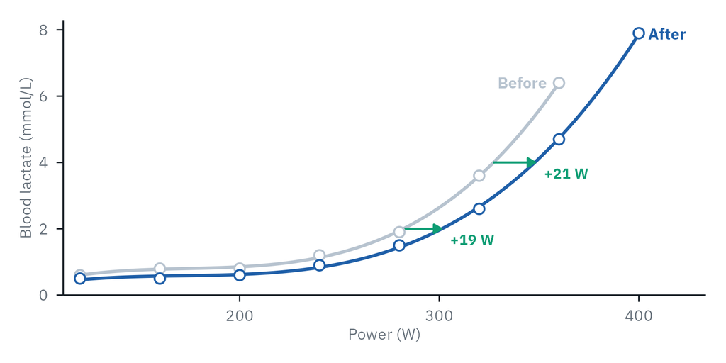

**compare_tests()**

Is a change larger than the noise of the method?

**curve_shift()**

How far the whole curve moved

**curve_shape()**

Did it shift, or change shape?

**lactate_trend()**

Where a series of tests is heading

**relative_thresholds()**

Per kg, % of peak intensity and heart rate

**reference_percentiles()**

Percentile among people of the same age and sex (cycling, general population)

### What the predictions rest on

| Sport | From | Source |
| --- | --- | --- |
| Running | IAT: 5 km to marathon; OBLA 4.0: marathon | Röcker 1998; Sjödin 1981 |
| Cycling | Six thresholds: 45-min time trial | Heuberger 2018, refitted |
| Rowing, swimming | Your own equation | `calibrate_performance()` |

## Report and style

```
report_start(results) |>
  report_header(name = "Ana", lab = "Our lab",
                logo = "logo.png") |>
  report_summary() |>
  report_zones() |>
  report_save("ana.html", pdf = TRUE)
```

**test_report()**

The default two-page report in one call; 2-5 tests and their `dates` for the progress

**report_*()**

Header, summary, zones, prediction, checks, test, methods, your own text

**lactate_report()**

Every threshold as a gt table for a paper

**gt_lactater()**

The same look for your own gt tables

[figure not shown]

The first page of a report: the two thresholds, what they mean, the zones.

### Plots

**theme_lactater()**

The look of lactater's plots, for your own

**lactater.style**

`options(lactater.style = "night")`, or `"journal"` for print

**lactater.font**

`options(lactater.font = "IBM Plex Sans")`

### Beyond the step test

**vlamax()**

The maximal lactate accumulation rate (V̇La<sub>max</sub>) from a sprint

### Learn more

Every method follows its original paper; the articles explain each one, its evidence, and how to read the checks.